# 각 나라 로렌츠 곡선 비교

4조

2015년 12월 2일

```r
library(xlsx)
data1 <- read.xlsx("data1.xlsx", 1, startRow=3, endRow=32, colIndex=3:7, colClasses=rep("numeric", 5), header=FALSE)
data1
data2 <-data1[-1,]
data2
data3 <-data2[-8,]
data3
data4 <-data3[-9,]
data4
data5 <- data4[-20,]
data5
data6 <- data5[-22,]
data6
```

[output not shown]

누적으로 변호

```r
x1 <- c(0,20,40,60,80,100)
cbind(x1, data8)
```

```
##     x1    2    3    4    5    6    7    8   10   12   13   14   15   16
## y0   0  0.0  0.0  0.0  0.0  0.0  0.0  0.0  0.0  0.0  0.0  0.0  0.0  0.0
## X3  20  6.6  8.8  6.8  5.3  7.6  5.9  7.0  4.9  3.3  3.4  3.3  4.2  5.0
## X4  40 13.3 12.9 10.8 10.2 11.5  9.4 11.6  8.8  9.0  7.7  7.3  8.4  9.2
## X5  60 18.1 17.0 15.1 15.2 15.5 13.9 16.1 12.8 14.6 12.4 11.9 12.9 13.6
## X6  80 23.9 22.1 21.4 22.2 21.1 21.2 22.2 19.5 22.7 19.3 19.7 20.6 20.7
## X7 100 38.0 39.2 46.0 47.1 44.3 49.7 43.0 54.1 50.5 57.2 57.9 53.9 51.6
##      17   18   19   20   21   22   24   25   27   28   29   30
## y0  0.0  0.0  0.0  0.0  0.0  0.0  0.0  0.0  0.0  0.0  0.0  0.0
## X3  4.3  5.7  3.2  4.1  4.2  5.2  8.9  8.9  7.6  7.4  7.4  5.8
## X4  9.0 10.2  7.8  8.7  9.2 10.0 13.2 13.8 12.1 11.7 11.0  9.3
## X5 13.9 14.7 12.6 13.8 14.5 15.1 17.3 17.9 16.5 15.8 15.0 13.6
## X6 21.2 21.3 20.2 20.7 21.9 22.8 22.8 23.2 22.3 21.6 20.8 20.3
## X7 51.6 48.1 56.3 52.7 50.1 46.9 37.8 36.3 41.6 43.6 45.7 51.1
```

```r
data9 <- cbind(x1, data8)
```

누적을 만든다.

```r
is.matrix(data9)
```

```
## [1] TRUE
```

```r
data10<- as.table(data9)
data10
```

```
##       x1     2     3     4     5     6     7     8    10    12    13    14
## y0   0.0   0.0   0.0   0.0   0.0   0.0   0.0   0.0   0.0   0.0   0.0   0.0
## X3  20.0   6.6   8.8   6.8   5.3   7.6   5.9   7.0   4.9   3.3   3.4   3.3
## X4  40.0  13.3  12.9  10.8  10.2  11.5   9.4  11.6   8.8   9.0   7.7   7.3
## X5  60.0  18.1  17.0  15.1  15.2  15.5  13.9  16.1  12.8  14.6  12.4  11.9
## X6  80.0  23.9  22.1  21.4  22.2  21.1  21.2  22.2  19.5  22.7  19.3  19.7
## X7 100.0  38.0  39.2  46.0  47.1  44.3  49.7  43.0  54.1  50.5  57.2  57.9
##       15    16    17    18    19    20    21    22    24    25    27    28
## y0   0.0   0.0   0.0   0.0   0.0   0.0   0.0   0.0   0.0   0.0   0.0   0.0
## X3   4.2   5.0   4.3   5.7   3.2   4.1   4.2   5.2   8.9   8.9   7.6   7.4
## X4   8.4   9.2   9.0  10.2   7.8   8.7   9.2  10.0  13.2  13.8  12.1  11.7
## X5  12.9  13.6  13.9  14.7  12.6  13.8  14.5  15.1  17.3  17.9  16.5  15.8
## X6  20.6  20.7  21.2  21.3  20.2  20.7  21.9  22.8  22.8  23.2  22.3  21.6
## X7  53.9  51.6  51.6  48.1  56.3  52.7  50.1  46.9  37.8  36.3  41.6  43.6
##       29    30
## y0   0.0   0.0
## X3   7.4   5.8
## X4  11.0   9.3
## X5  15.0  13.6
## X6  20.8  20.3
## X7  45.7  51.1
```

```r
cbind(x = data10[,1], apply(data8[, 1:25], 2, cumsum))
```

```
##      x    2     3     4     5     6     7    8    10    12    13    14
## y0   0  0.0   0.0   0.0   0.0   0.0   0.0  0.0   0.0   0.0   0.0   0.0
## X3  20  6.6   8.8   6.8   5.3   7.6   5.9  7.0   4.9   3.3   3.4   3.3
## X4  40 19.9  21.7  17.6  15.5  19.1  15.3 18.6  13.7  12.3  11.1  10.6
## X5  60 38.0  38.7  32.7  30.7  34.6  29.2 34.7  26.5  26.9  23.5  22.5
## X6  80 61.9  60.8  54.1  52.9  55.7  50.4 56.9  46.0  49.6  42.8  42.2
## X7 100 99.9 100.0 100.1 100.0 100.0 100.1 99.9 100.1 100.1 100.0 100.1
##       15    16    17    18    19    20   21    22    24    25    27    28
## y0   0.0   0.0   0.0   0.0   0.0   0.0  0.0   0.0   0.0   0.0   0.0   0.0
## X3   4.2   5.0   4.3   5.7   3.2   4.1  4.2   5.2   8.9   8.9   7.6   7.4
## X4  12.6  14.2  13.3  15.9  11.0  12.8 13.4  15.2  22.1  22.7  19.7  19.1
## X5  25.5  27.8  27.2  30.6  23.6  26.6 27.9  30.3  39.4  40.6  36.2  34.9
## X6  46.1  48.5  48.4  51.9  43.8  47.3 49.8  53.1  62.2  63.8  58.5  56.5
## X7 100.0 100.1 100.0 100.0 100.1 100.0 99.9 100.0 100.0 100.1 100.1 100.1
##      29    30
## y0  0.0   0.0
## X3  7.4   5.8
## X4 18.4  15.1
## X5 33.4  28.7
## X6 54.2  49.0
## X7 99.9 100.1
```

```r
datadown1 <- read.xlsx("data1.xlsx", 1, startRow=3, endRow=32, colIndex=2, colClasses="numeric", header=FALSE)
datadown1
```

```
##     X2
## 1   NA
## 2  2.2
## 3  3.7
## 4  2.9
## 5  1.9
## 6  3.3
## 7  2.5
## 8  2.9
## 9   NA
## 10 1.9
## 11  NA
## 12 0.8
## 13 1.0
## 14 1.1
```

[output cut: 16 more lines]

```r
datadown2 <-datadown1[-1,]
datadown2
```

```
##  [1] 2.2 3.7 2.9 1.9 3.3 2.5 2.9  NA 1.9  NA 0.8 1.0 1.1 1.5 1.9 1.4 2.2
## [18] 1.0 1.4 1.4 1.9  NA 3.7 3.7  NA 3.1 3.0 3.2 2.5
```

```r
datadown3 <-datadown2[-8]
datadown3
```

```
##  [1] 2.2 3.7 2.9 1.9 3.3 2.5 2.9 1.9  NA 0.8 1.0 1.1 1.5 1.9 1.4 2.2 1.0
## [18] 1.4 1.4 1.9  NA 3.7 3.7  NA 3.1 3.0 3.2 2.5
```

```r
datadown4 <-datadown3[-9]
datadown4
```

```
##  [1] 2.2 3.7 2.9 1.9 3.3 2.5 2.9 1.9 0.8 1.0 1.1 1.5 1.9 1.4 2.2 1.0 1.4
## [18] 1.4 1.9  NA 3.7 3.7  NA 3.1 3.0 3.2 2.5
```

```r
datadown5 <- datadown4[-20]
datadown5
```

```
##  [1] 2.2 3.7 2.9 1.9 3.3 2.5 2.9 1.9 0.8 1.0 1.1 1.5 1.9 1.4 2.2 1.0 1.4
## [18] 1.4 1.9 3.7 3.7  NA 3.1 3.0 3.2 2.5
```

```r
datadown6 <- datadown5[-22]
datadown6
```

```
##  [1] 2.2 3.7 2.9 1.9 3.3 2.5 2.9 1.9 0.8 1.0 1.1 1.5 1.9 1.4 2.2 1.0 1.4
## [18] 1.4 1.9 3.7 3.7 3.1 3.0 3.2 2.5
```

```r
datadown7 <- as.matrix(datadown6)
datadown7
```

```
##       [,1]
##  [1,]  2.2
##  [2,]  3.7
##  [3,]  2.9
##  [4,]  1.9
##  [5,]  3.3
##  [6,]  2.5
##  [7,]  2.9
##  [8,]  1.9
##  [9,]  0.8
## [10,]  1.0
## [11,]  1.1
## [12,]  1.5
## [13,]  1.9
## [14,]  1.4
## [15,]  2.2
## [16,]  1.0
## [17,]  1.4
## [18,]  1.4
## [19,]  1.9
## [20,]  3.7
## [21,]  3.7
## [22,]  3.1
## [23,]  3.0
## [24,]  3.2
## [25,]  2.5
```

```r
datadown8 <- t(datadown7)
datadown8
```

```
##      [,1] [,2] [,3] [,4] [,5] [,6] [,7] [,8] [,9] [,10] [,11] [,12] [,13]
## [1,]  2.2  3.7  2.9  1.9  3.3  2.5  2.9  1.9  0.8     1   1.1   1.5   1.9
##      [,14] [,15] [,16] [,17] [,18] [,19] [,20] [,21] [,22] [,23] [,24]
## [1,]   1.4   2.2     1   1.4   1.4   1.9   3.7   3.7   3.1     3   3.2
##      [,25]
## [1,]   2.5
```

```r
datadown9 <- as.table(datadown8)
datadown10<- as.numeric(datadown9)
datadown10
```

```
##  [1] 2.2 3.7 2.9 1.9 3.3 2.5 2.9 1.9 0.8 1.0 1.1 1.5 1.9 1.4 2.2 1.0 1.4
## [18] 1.4 1.9 3.7 3.7 3.1 3.0 3.2 2.5
```

```r
data8
```

```
##       2    3    4    5    6    7    8   10   12   13   14   15   16   17
## y0  0.0  0.0  0.0  0.0  0.0  0.0  0.0  0.0  0.0  0.0  0.0  0.0  0.0  0.0
## X3  6.6  8.8  6.8  5.3  7.6  5.9  7.0  4.9  3.3  3.4  3.3  4.2  5.0  4.3
## X4 13.3 12.9 10.8 10.2 11.5  9.4 11.6  8.8  9.0  7.7  7.3  8.4  9.2  9.0
## X5 18.1 17.0 15.1 15.2 15.5 13.9 16.1 12.8 14.6 12.4 11.9 12.9 13.6 13.9
## X6 23.9 22.1 21.4 22.2 21.1 21.2 22.2 19.5 22.7 19.3 19.7 20.6 20.7 21.2
## X7 38.0 39.2 46.0 47.1 44.3 49.7 43.0 54.1 50.5 57.2 57.9 53.9 51.6 51.6
##      18   19   20   21   22   24   25   27   28   29   30
## y0  0.0  0.0  0.0  0.0  0.0  0.0  0.0  0.0  0.0  0.0  0.0
## X3  5.7  3.2  4.1  4.2  5.2  8.9  8.9  7.6  7.4  7.4  5.8
## X4 10.2  7.8  8.7  9.2 10.0 13.2 13.8 12.1 11.7 11.0  9.3
## X5 14.7 12.6 13.8 14.5 15.1 17.3 17.9 16.5 15.8 15.0 13.6
## X6 21.3 20.2 20.7 21.9 22.8 22.8 23.2 22.3 21.6 20.8 20.3
## X7 48.1 56.3 52.7 50.1 46.9 37.8 36.3 41.6 43.6 45.7 51.1
```

```r
datat1 <-  data8[-1,]
datat1
```

```
##       2    3    4    5    6    7    8   10   12   13   14   15   16   17
## X3  6.6  8.8  6.8  5.3  7.6  5.9  7.0  4.9  3.3  3.4  3.3  4.2  5.0  4.3
## X4 13.3 12.9 10.8 10.2 11.5  9.4 11.6  8.8  9.0  7.7  7.3  8.4  9.2  9.0
## X5 18.1 17.0 15.1 15.2 15.5 13.9 16.1 12.8 14.6 12.4 11.9 12.9 13.6 13.9
## X6 23.9 22.1 21.4 22.2 21.1 21.2 22.2 19.5 22.7 19.3 19.7 20.6 20.7 21.2
## X7 38.0 39.2 46.0 47.1 44.3 49.7 43.0 54.1 50.5 57.2 57.9 53.9 51.6 51.6
##      18   19   20   21   22   24   25   27   28   29   30
## X3  5.7  3.2  4.1  4.2  5.2  8.9  8.9  7.6  7.4  7.4  5.8
## X4 10.2  7.8  8.7  9.2 10.0 13.2 13.8 12.1 11.7 11.0  9.3
## X5 14.7 12.6 13.8 14.5 15.1 17.3 17.9 16.5 15.8 15.0 13.6
## X6 21.3 20.2 20.7 21.9 22.8 22.8 23.2 22.3 21.6 20.8 20.3
## X7 48.1 56.3 52.7 50.1 46.9 37.8 36.3 41.6 43.6 45.7 51.1
```

```r
datat2 <- datat1[1,]
datat3<- as.matrix(datat2)
datat4 <-t(datat3)
datat4
```

```
##        2   3   4   5   6   7 8  10  12  13  14  15 16  17  18  19  20  21
## [1,] 6.6 8.8 6.8 5.3 7.6 5.9 7 4.9 3.3 3.4 3.3 4.2  5 4.3 5.7 3.2 4.1 4.2
##       22  24  25  27  28  29  30
## [1,] 5.2 8.9 8.9 7.6 7.4 7.4 5.8
```

```r
datat5<-as.table(datat4)
datat6 <- as.numeric(datat5)
datat6
```

```
##  [1] 6.6 8.8 6.8 5.3 7.6 5.9 7.0 4.9 3.3 3.4 3.3 4.2 5.0 4.3 5.7 3.2 4.1
## [18] 4.2 5.2 8.9 8.9 7.6 7.4 7.4 5.8
```

```r
datat7 <- datat6 - datadown10
datat7
```

```
##  [1] 4.4 5.1 3.9 3.4 4.3 3.4 4.1 3.0 2.5 2.4 2.2 2.7 3.1 2.9 3.5 2.2 2.7
## [18] 2.8 3.3 5.2 5.2 4.5 4.4 4.2 3.3
```

```r
datat8<- as.matrix(datat7)
datat9 <-t(datat8)
datat9
```

```
##      [,1] [,2] [,3] [,4] [,5] [,6] [,7] [,8] [,9] [,10] [,11] [,12] [,13]
## [1,]  4.4  5.1  3.9  3.4  4.3  3.4  4.1    3  2.5   2.4   2.2   2.7   3.1
##      [,14] [,15] [,16] [,17] [,18] [,19] [,20] [,21] [,22] [,23] [,24]
## [1,]   2.9   3.5   2.2   2.7   2.8   3.3   5.2   5.2   4.5   4.4   4.2
##      [,25]
## [1,]   3.3
```

```r
newdata1 <- datat1[-1,]
newdata1
```

```
##       2    3    4    5    6    7    8   10   12   13   14   15   16   17
## X4 13.3 12.9 10.8 10.2 11.5  9.4 11.6  8.8  9.0  7.7  7.3  8.4  9.2  9.0
## X5 18.1 17.0 15.1 15.2 15.5 13.9 16.1 12.8 14.6 12.4 11.9 12.9 13.6 13.9
## X6 23.9 22.1 21.4 22.2 21.1 21.2 22.2 19.5 22.7 19.3 19.7 20.6 20.7 21.2
## X7 38.0 39.2 46.0 47.1 44.3 49.7 43.0 54.1 50.5 57.2 57.9 53.9 51.6 51.6
##      18   19   20   21   22   24   25   27   28   29   30
## X4 10.2  7.8  8.7  9.2 10.0 13.2 13.8 12.1 11.7 11.0  9.3
## X5 14.7 12.6 13.8 14.5 15.1 17.3 17.9 16.5 15.8 15.0 13.6
## X6 21.3 20.2 20.7 21.9 22.8 22.8 23.2 22.3 21.6 20.8 20.3
## X7 48.1 56.3 52.7 50.1 46.9 37.8 36.3 41.6 43.6 45.7 51.1
```

```r
newdata2 <- rbind(datat9, newdata1)
newdata2
```

```
##       2    3    4    5    6    7    8   10   12   13   14   15   16   17
##     4.4  5.1  3.9  3.4  4.3  3.4  4.1  3.0  2.5  2.4  2.2  2.7  3.1  2.9
## X4 13.3 12.9 10.8 10.2 11.5  9.4 11.6  8.8  9.0  7.7  7.3  8.4  9.2  9.0
## X5 18.1 17.0 15.1 15.2 15.5 13.9 16.1 12.8 14.6 12.4 11.9 12.9 13.6 13.9
## X6 23.9 22.1 21.4 22.2 21.1 21.2 22.2 19.5 22.7 19.3 19.7 20.6 20.7 21.2
## X7 38.0 39.2 46.0 47.1 44.3 49.7 43.0 54.1 50.5 57.2 57.9 53.9 51.6 51.6
##      18   19   20   21   22   24   25   27   28   29   30
##     3.5  2.2  2.7  2.8  3.3  5.2  5.2  4.5  4.4  4.2  3.3
## X4 10.2  7.8  8.7  9.2 10.0 13.2 13.8 12.1 11.7 11.0  9.3
## X5 14.7 12.6 13.8 14.5 15.1 17.3 17.9 16.5 15.8 15.0 13.6
## X6 21.3 20.2 20.7 21.9 22.8 22.8 23.2 22.3 21.6 20.8 20.3
## X7 48.1 56.3 52.7 50.1 46.9 37.8 36.3 41.6 43.6 45.7 51.1
```

```r
newdata3 <- rbind(datadown10, newdata2)
newdata4<- rbind(y0, newdata3)
newdata4
```

```
##               2    3    4    5    6    7    8   10   12   13   14   15
## y0          0.0  0.0  0.0  0.0  0.0  0.0  0.0  0.0  0.0  0.0  0.0  0.0
## datadown10  2.2  3.7  2.9  1.9  3.3  2.5  2.9  1.9  0.8  1.0  1.1  1.5
##             4.4  5.1  3.9  3.4  4.3  3.4  4.1  3.0  2.5  2.4  2.2  2.7
## X4         13.3 12.9 10.8 10.2 11.5  9.4 11.6  8.8  9.0  7.7  7.3  8.4
## X5         18.1 17.0 15.1 15.2 15.5 13.9 16.1 12.8 14.6 12.4 11.9 12.9
## X6         23.9 22.1 21.4 22.2 21.1 21.2 22.2 19.5 22.7 19.3 19.7 20.6
## X7         38.0 39.2 46.0 47.1 44.3 49.7 43.0 54.1 50.5 57.2 57.9 53.9
##              16   17   18   19   20   21   22   24   25   27   28   29
## y0          0.0  0.0  0.0  0.0  0.0  0.0  0.0  0.0  0.0  0.0  0.0  0.0
## datadown10  1.9  1.4  2.2  1.0  1.4  1.4  1.9  3.7  3.7  3.1  3.0  3.2
##             3.1  2.9  3.5  2.2  2.7  2.8  3.3  5.2  5.2  4.5  4.4  4.2
## X4          9.2  9.0 10.2  7.8  8.7  9.2 10.0 13.2 13.8 12.1 11.7 11.0
## X5         13.6 13.9 14.7 12.6 13.8 14.5 15.1 17.3 17.9 16.5 15.8 15.0
## X6         20.7 21.2 21.3 20.2 20.7 21.9 22.8 22.8 23.2 22.3 21.6 20.8
## X7         51.6 51.6 48.1 56.3 52.7 50.1 46.9 37.8 36.3 41.6 43.6 45.7
##              30
## y0          0.0
## datadown10  2.5
##             3.3
## X4          9.3
## X5         13.6
## X6         20.3
## X7         51.1
```

하위 정리를 끝내면 상위를 정리한다.

```r
dataup1 <- read.xlsx("data1.xlsx", 1, startRow=3, endRow=32, colIndex=8, colClasses="numeric", header=FALSE)
dataup1
```

```
##      X8
## 1    NA
## 2  22.6
## 3  24.8
## 4  30.8
## 5  30.9
## 6  29.7
## 7  33.5
## 8  27.8
## 9    NA
## 10 38.9
## 11   NA
## 12 33.6
## 13 41.7
## 14 42.0
```

[output cut: 16 more lines]

```r
dataup2 <-dataup1[-1,]
dataup2
```

```
##  [1] 22.6 24.8 30.8 30.9 29.7 33.5 27.8   NA 38.9   NA 33.6 41.7 42.0 37.1
## [15] 35.8 35.4 32.5 39.9 37.3 33.8 30.2   NA 22.9 21.5   NA 26.5 28.9 31.1
## [29] 35.8
```

```r
dataup3 <-dataup2[-8]
dataup3
```

```
##  [1] 22.6 24.8 30.8 30.9 29.7 33.5 27.8 38.9   NA 33.6 41.7 42.0 37.1 35.8
## [15] 35.4 32.5 39.9 37.3 33.8 30.2   NA 22.9 21.5   NA 26.5 28.9 31.1 35.8
```

```r
dataup4 <-dataup3[-9]
dataup4
```

```
##  [1] 22.6 24.8 30.8 30.9 29.7 33.5 27.8 38.9 33.6 41.7 42.0 37.1 35.8 35.4
## [15] 32.5 39.9 37.3 33.8 30.2   NA 22.9 21.5   NA 26.5 28.9 31.1 35.8
```

```r
dataup5 <- dataup4[-20]
dataup5
```

```
##  [1] 22.6 24.8 30.8 30.9 29.7 33.5 27.8 38.9 33.6 41.7 42.0 37.1 35.8 35.4
## [15] 32.5 39.9 37.3 33.8 30.2 22.9 21.5   NA 26.5 28.9 31.1 35.8
```

```r
dataup6 <- dataup5[-22]
dataup6
```

```
##  [1] 22.6 24.8 30.8 30.9 29.7 33.5 27.8 38.9 33.6 41.7 42.0 37.1 35.8 35.4
## [15] 32.5 39.9 37.3 33.8 30.2 22.9 21.5 26.5 28.9 31.1 35.8
```

```r
dataup7 <- as.matrix(dataup6)
dataup7
```

```
##       [,1]
##  [1,] 22.6
##  [2,] 24.8
##  [3,] 30.8
##  [4,] 30.9
##  [5,] 29.7
##  [6,] 33.5
##  [7,] 27.8
##  [8,] 38.9
##  [9,] 33.6
## [10,] 41.7
## [11,] 42.0
## [12,] 37.1
## [13,] 35.8
## [14,] 35.4
## [15,] 32.5
## [16,] 39.9
## [17,] 37.3
## [18,] 33.8
## [19,] 30.2
## [20,] 22.9
## [21,] 21.5
## [22,] 26.5
## [23,] 28.9
## [24,] 31.1
## [25,] 35.8
```

```r
dataup8 <- t(dataup7)
dataup8
```

```
##      [,1] [,2] [,3] [,4] [,5] [,6] [,7] [,8] [,9] [,10] [,11] [,12] [,13]
## [1,] 22.6 24.8 30.8 30.9 29.7 33.5 27.8 38.9 33.6  41.7    42  37.1  35.8
##      [,14] [,15] [,16] [,17] [,18] [,19] [,20] [,21] [,22] [,23] [,24]
## [1,]  35.4  32.5  39.9  37.3  33.8  30.2  22.9  21.5  26.5  28.9  31.1
##      [,25]
## [1,]  35.8
```

```r
dataup9 <- as.table(dataup8)
dataup10<- as.numeric(dataup9)
dataup10
```

```
##  [1] 22.6 24.8 30.8 30.9 29.7 33.5 27.8 38.9 33.6 41.7 42.0 37.1 35.8 35.4
## [15] 32.5 39.9 37.3 33.8 30.2 22.9 21.5 26.5 28.9 31.1 35.8
```

```r
newdata4
```

```
##               2    3    4    5    6    7    8   10   12   13   14   15
## y0          0.0  0.0  0.0  0.0  0.0  0.0  0.0  0.0  0.0  0.0  0.0  0.0
## datadown10  2.2  3.7  2.9  1.9  3.3  2.5  2.9  1.9  0.8  1.0  1.1  1.5
##             4.4  5.1  3.9  3.4  4.3  3.4  4.1  3.0  2.5  2.4  2.2  2.7
## X4         13.3 12.9 10.8 10.2 11.5  9.4 11.6  8.8  9.0  7.7  7.3  8.4
## X5         18.1 17.0 15.1 15.2 15.5 13.9 16.1 12.8 14.6 12.4 11.9 12.9
## X6         23.9 22.1 21.4 22.2 21.1 21.2 22.2 19.5 22.7 19.3 19.7 20.6
## X7         38.0 39.2 46.0 47.1 44.3 49.7 43.0 54.1 50.5 57.2 57.9 53.9
##              16   17   18   19   20   21   22   24   25   27   28   29
## y0          0.0  0.0  0.0  0.0  0.0  0.0  0.0  0.0  0.0  0.0  0.0  0.0
## datadown10  1.9  1.4  2.2  1.0  1.4  1.4  1.9  3.7  3.7  3.1  3.0  3.2
##             3.1  2.9  3.5  2.2  2.7  2.8  3.3  5.2  5.2  4.5  4.4  4.2
## X4          9.2  9.0 10.2  7.8  8.7  9.2 10.0 13.2 13.8 12.1 11.7 11.0
## X5         13.6 13.9 14.7 12.6 13.8 14.5 15.1 17.3 17.9 16.5 15.8 15.0
## X6         20.7 21.2 21.3 20.2 20.7 21.9 22.8 22.8 23.2 22.3 21.6 20.8
## X7         51.6 51.6 48.1 56.3 52.7 50.1 46.9 37.8 36.3 41.6 43.6 45.7
##              30
## y0          0.0
## datadown10  2.5
##             3.3
## X4          9.3
## X5         13.6
## X6         20.3
## X7         51.1
```

```r
dataq1 <-newdata4[7,]
dataq1
```

```
##    2    3    4    5    6    7    8   10   12   13   14   15   16   17   18
## 38.0 39.2 46.0 47.1 44.3 49.7 43.0 54.1 50.5 57.2 57.9 53.9 51.6 51.6 48.1
##   19   20   21   22   24   25   27   28   29   30
## 56.3 52.7 50.1 46.9 37.8 36.3 41.6 43.6 45.7 51.1
```

```r
dataq2<-as.numeric(dataq1)
dataq2
```

```
##  [1] 38.0 39.2 46.0 47.1 44.3 49.7 43.0 54.1 50.5 57.2 57.9 53.9 51.6 51.6
## [15] 48.1 56.3 52.7 50.1 46.9 37.8 36.3 41.6 43.6 45.7 51.1
```

```r
dataq3<- dataq2-dataup10
dataq3
```

```
##  [1] 15.4 14.4 15.2 16.2 14.6 16.2 15.2 15.2 16.9 15.5 15.9 16.8 15.8 16.2
## [15] 15.6 16.4 15.4 16.3 16.7 14.9 14.8 15.1 14.7 14.6 15.3
```

```r
dataq4<-as.matrix(dataq3)
dataq5 <- t(dataq4)
dataq5
```

```
##      [,1] [,2] [,3] [,4] [,5] [,6] [,7] [,8] [,9] [,10] [,11] [,12] [,13]
## [1,] 15.4 14.4 15.2 16.2 14.6 16.2 15.2 15.2 16.9  15.5  15.9  16.8  15.8
##      [,14] [,15] [,16] [,17] [,18] [,19] [,20] [,21] [,22] [,23] [,24]
## [1,]  16.2  15.6  16.4  15.4  16.3  16.7  14.9  14.8  15.1  14.7  14.6
##      [,25]
## [1,]  15.3
```

```r
newdata4
```

```
##               2    3    4    5    6    7    8   10   12   13   14   15
## y0          0.0  0.0  0.0  0.0  0.0  0.0  0.0  0.0  0.0  0.0  0.0  0.0
## datadown10  2.2  3.7  2.9  1.9  3.3  2.5  2.9  1.9  0.8  1.0  1.1  1.5
##             4.4  5.1  3.9  3.4  4.3  3.4  4.1  3.0  2.5  2.4  2.2  2.7
## X4         13.3 12.9 10.8 10.2 11.5  9.4 11.6  8.8  9.0  7.7  7.3  8.4
## X5         18.1 17.0 15.1 15.2 15.5 13.9 16.1 12.8 14.6 12.4 11.9 12.9
## X6         23.9 22.1 21.4 22.2 21.1 21.2 22.2 19.5 22.7 19.3 19.7 20.6
## X7         38.0 39.2 46.0 47.1 44.3 49.7 43.0 54.1 50.5 57.2 57.9 53.9
##              16   17   18   19   20   21   22   24   25   27   28   29
## y0          0.0  0.0  0.0  0.0  0.0  0.0  0.0  0.0  0.0  0.0  0.0  0.0
## datadown10  1.9  1.4  2.2  1.0  1.4  1.4  1.9  3.7  3.7  3.1  3.0  3.2
##             3.1  2.9  3.5  2.2  2.7  2.8  3.3  5.2  5.2  4.5  4.4  4.2
## X4          9.2  9.0 10.2  7.8  8.7  9.2 10.0 13.2 13.8 12.1 11.7 11.0
## X5         13.6 13.9 14.7 12.6 13.8 14.5 15.1 17.3 17.9 16.5 15.8 15.0
## X6         20.7 21.2 21.3 20.2 20.7 21.9 22.8 22.8 23.2 22.3 21.6 20.8
## X7         51.6 51.6 48.1 56.3 52.7 50.1 46.9 37.8 36.3 41.6 43.6 45.7
##              30
## y0          0.0
## datadown10  2.5
##             3.3
## X4          9.3
## X5         13.6
## X6         20.3
## X7         51.1
```

```r
newdata5 <- newdata4[-7,]
newdata6 <- rbind(newdata5, dataq5)
newdata6
```

```
##               2    3    4    5    6    7    8   10   12   13   14   15
## y0          0.0  0.0  0.0  0.0  0.0  0.0  0.0  0.0  0.0  0.0  0.0  0.0
## datadown10  2.2  3.7  2.9  1.9  3.3  2.5  2.9  1.9  0.8  1.0  1.1  1.5
##             4.4  5.1  3.9  3.4  4.3  3.4  4.1  3.0  2.5  2.4  2.2  2.7
## X4         13.3 12.9 10.8 10.2 11.5  9.4 11.6  8.8  9.0  7.7  7.3  8.4
## X5         18.1 17.0 15.1 15.2 15.5 13.9 16.1 12.8 14.6 12.4 11.9 12.9
## X6         23.9 22.1 21.4 22.2 21.1 21.2 22.2 19.5 22.7 19.3 19.7 20.6
##            15.4 14.4 15.2 16.2 14.6 16.2 15.2 15.2 16.9 15.5 15.9 16.8
##              16   17   18   19   20   21   22   24   25   27   28   29
## y0          0.0  0.0  0.0  0.0  0.0  0.0  0.0  0.0  0.0  0.0  0.0  0.0
## datadown10  1.9  1.4  2.2  1.0  1.4  1.4  1.9  3.7  3.7  3.1  3.0  3.2
##             3.1  2.9  3.5  2.2  2.7  2.8  3.3  5.2  5.2  4.5  4.4  4.2
## X4          9.2  9.0 10.2  7.8  8.7  9.2 10.0 13.2 13.8 12.1 11.7 11.0
## X5         13.6 13.9 14.7 12.6 13.8 14.5 15.1 17.3 17.9 16.5 15.8 15.0
## X6         20.7 21.2 21.3 20.2 20.7 21.9 22.8 22.8 23.2 22.3 21.6 20.8
##            15.8 16.2 15.6 16.4 15.4 16.3 16.7 14.9 14.8 15.1 14.7 14.6
##              30
## y0          0.0
## datadown10  2.5
##             3.3
## X4          9.3
## X5         13.6
## X6         20.3
##            15.3
```

```r
newdata7 <- rbind(newdata6, dataup8)
newdata7
```

```
##               2    3    4    5    6    7    8   10   12   13   14   15
## y0          0.0  0.0  0.0  0.0  0.0  0.0  0.0  0.0  0.0  0.0  0.0  0.0
## datadown10  2.2  3.7  2.9  1.9  3.3  2.5  2.9  1.9  0.8  1.0  1.1  1.5
##             4.4  5.1  3.9  3.4  4.3  3.4  4.1  3.0  2.5  2.4  2.2  2.7
## X4         13.3 12.9 10.8 10.2 11.5  9.4 11.6  8.8  9.0  7.7  7.3  8.4
## X5         18.1 17.0 15.1 15.2 15.5 13.9 16.1 12.8 14.6 12.4 11.9 12.9
## X6         23.9 22.1 21.4 22.2 21.1 21.2 22.2 19.5 22.7 19.3 19.7 20.6
##            15.4 14.4 15.2 16.2 14.6 16.2 15.2 15.2 16.9 15.5 15.9 16.8
##            22.6 24.8 30.8 30.9 29.7 33.5 27.8 38.9 33.6 41.7 42.0 37.1
##              16   17   18   19   20   21   22   24   25   27   28   29
## y0          0.0  0.0  0.0  0.0  0.0  0.0  0.0  0.0  0.0  0.0  0.0  0.0
## datadown10  1.9  1.4  2.2  1.0  1.4  1.4  1.9  3.7  3.7  3.1  3.0  3.2
##             3.1  2.9  3.5  2.2  2.7  2.8  3.3  5.2  5.2  4.5  4.4  4.2
## X4          9.2  9.0 10.2  7.8  8.7  9.2 10.0 13.2 13.8 12.1 11.7 11.0
## X5         13.6 13.9 14.7 12.6 13.8 14.5 15.1 17.3 17.9 16.5 15.8 15.0
## X6         20.7 21.2 21.3 20.2 20.7 21.9 22.8 22.8 23.2 22.3 21.6 20.8
##            15.8 16.2 15.6 16.4 15.4 16.3 16.7 14.9 14.8 15.1 14.7 14.6
##            35.8 35.4 32.5 39.9 37.3 33.8 30.2 22.9 21.5 26.5 28.9 31.1
##              30
## y0          0.0
## datadown10  2.5
##             3.3
## X4          9.3
## X5         13.6
## X6         20.3
##            15.3
##            35.8
```

```r
x2 <- c(0,10,20,40,60,80,90,100)
cbind(x2, newdata7)
```

```
##             x2    2    3    4    5    6    7    8   10   12   13   14   15
## y0           0  0.0  0.0  0.0  0.0  0.0  0.0  0.0  0.0  0.0  0.0  0.0  0.0
## datadown10  10  2.2  3.7  2.9  1.9  3.3  2.5  2.9  1.9  0.8  1.0  1.1  1.5
##             20  4.4  5.1  3.9  3.4  4.3  3.4  4.1  3.0  2.5  2.4  2.2  2.7
## X4          40 13.3 12.9 10.8 10.2 11.5  9.4 11.6  8.8  9.0  7.7  7.3  8.4
## X5          60 18.1 17.0 15.1 15.2 15.5 13.9 16.1 12.8 14.6 12.4 11.9 12.9
## X6          80 23.9 22.1 21.4 22.2 21.1 21.2 22.2 19.5 22.7 19.3 19.7 20.6
##             90 15.4 14.4 15.2 16.2 14.6 16.2 15.2 15.2 16.9 15.5 15.9 16.8
##            100 22.6 24.8 30.8 30.9 29.7 33.5 27.8 38.9 33.6 41.7 42.0 37.1
##              16   17   18   19   20   21   22   24   25   27   28   29
## y0          0.0  0.0  0.0  0.0  0.0  0.0  0.0  0.0  0.0  0.0  0.0  0.0
## datadown10  1.9  1.4  2.2  1.0  1.4  1.4  1.9  3.7  3.7  3.1  3.0  3.2
##             3.1  2.9  3.5  2.2  2.7  2.8  3.3  5.2  5.2  4.5  4.4  4.2
## X4          9.2  9.0 10.2  7.8  8.7  9.2 10.0 13.2 13.8 12.1 11.7 11.0
## X5         13.6 13.9 14.7 12.6 13.8 14.5 15.1 17.3 17.9 16.5 15.8 15.0
## X6         20.7 21.2 21.3 20.2 20.7 21.9 22.8 22.8 23.2 22.3 21.6 20.8
##            15.8 16.2 15.6 16.4 15.4 16.3 16.7 14.9 14.8 15.1 14.7 14.6
##            35.8 35.4 32.5 39.9 37.3 33.8 30.2 22.9 21.5 26.5 28.9 31.1
##              30
## y0          0.0
## datadown10  2.5
##             3.3
## X4          9.3
## X5         13.6
## X6         20.3
##            15.3
##            35.8
```

```r
newdata8 <- cbind(x2, newdata7)
newdata8
```

```
##             x2    2    3    4    5    6    7    8   10   12   13   14   15
## y0           0  0.0  0.0  0.0  0.0  0.0  0.0  0.0  0.0  0.0  0.0  0.0  0.0
## datadown10  10  2.2  3.7  2.9  1.9  3.3  2.5  2.9  1.9  0.8  1.0  1.1  1.5
##             20  4.4  5.1  3.9  3.4  4.3  3.4  4.1  3.0  2.5  2.4  2.2  2.7
## X4          40 13.3 12.9 10.8 10.2 11.5  9.4 11.6  8.8  9.0  7.7  7.3  8.4
## X5          60 18.1 17.0 15.1 15.2 15.5 13.9 16.1 12.8 14.6 12.4 11.9 12.9
## X6          80 23.9 22.1 21.4 22.2 21.1 21.2 22.2 19.5 22.7 19.3 19.7 20.6
##             90 15.4 14.4 15.2 16.2 14.6 16.2 15.2 15.2 16.9 15.5 15.9 16.8
##            100 22.6 24.8 30.8 30.9 29.7 33.5 27.8 38.9 33.6 41.7 42.0 37.1
##              16   17   18   19   20   21   22   24   25   27   28   29
## y0          0.0  0.0  0.0  0.0  0.0  0.0  0.0  0.0  0.0  0.0  0.0  0.0
## datadown10  1.9  1.4  2.2  1.0  1.4  1.4  1.9  3.7  3.7  3.1  3.0  3.2
##             3.1  2.9  3.5  2.2  2.7  2.8  3.3  5.2  5.2  4.5  4.4  4.2
## X4          9.2  9.0 10.2  7.8  8.7  9.2 10.0 13.2 13.8 12.1 11.7 11.0
## X5         13.6 13.9 14.7 12.6 13.8 14.5 15.1 17.3 17.9 16.5 15.8 15.0
## X6         20.7 21.2 21.3 20.2 20.7 21.9 22.8 22.8 23.2 22.3 21.6 20.8
##            15.8 16.2 15.6 16.4 15.4 16.3 16.7 14.9 14.8 15.1 14.7 14.6
##            35.8 35.4 32.5 39.9 37.3 33.8 30.2 22.9 21.5 26.5 28.9 31.1
##              30
## y0          0.0
## datadown10  2.5
##             3.3
## X4          9.3
## X5         13.6
## X6         20.3
##            15.3
##            35.8
```

```r
newdata9<- as.table(newdata8)
newdata9
```

```
##               x2     2     3     4     5     6     7     8    10    12
## y0           0.0   0.0   0.0   0.0   0.0   0.0   0.0   0.0   0.0   0.0
## datadown10  10.0   2.2   3.7   2.9   1.9   3.3   2.5   2.9   1.9   0.8
##             20.0   4.4   5.1   3.9   3.4   4.3   3.4   4.1   3.0   2.5
## X4          40.0  13.3  12.9  10.8  10.2  11.5   9.4  11.6   8.8   9.0
## X5          60.0  18.1  17.0  15.1  15.2  15.5  13.9  16.1  12.8  14.6
## X6          80.0  23.9  22.1  21.4  22.2  21.1  21.2  22.2  19.5  22.7
##             90.0  15.4  14.4  15.2  16.2  14.6  16.2  15.2  15.2  16.9
##            100.0  22.6  24.8  30.8  30.9  29.7  33.5  27.8  38.9  33.6
##               13    14    15    16    17    18    19    20    21    22
## y0           0.0   0.0   0.0   0.0   0.0   0.0   0.0   0.0   0.0   0.0
## datadown10   1.0   1.1   1.5   1.9   1.4   2.2   1.0   1.4   1.4   1.9
##              2.4   2.2   2.7   3.1   2.9   3.5   2.2   2.7   2.8   3.3
## X4           7.7   7.3   8.4   9.2   9.0  10.2   7.8   8.7   9.2  10.0
## X5          12.4  11.9  12.9  13.6  13.9  14.7  12.6  13.8  14.5  15.1
## X6          19.3  19.7  20.6  20.7  21.2  21.3  20.2  20.7  21.9  22.8
##             15.5  15.9  16.8  15.8  16.2  15.6  16.4  15.4  16.3  16.7
##             41.7  42.0  37.1  35.8  35.4  32.5  39.9  37.3  33.8  30.2
##               24    25    27    28    29    30
## y0           0.0   0.0   0.0   0.0   0.0   0.0
## datadown10   3.7   3.7   3.1   3.0   3.2   2.5
##              5.2   5.2   4.5   4.4   4.2   3.3
## X4          13.2  13.8  12.1  11.7  11.0   9.3
## X5          17.3  17.9  16.5  15.8  15.0  13.6
## X6          22.8  23.2  22.3  21.6  20.8  20.3
##             14.9  14.8  15.1  14.7  14.6  15.3
##             22.9  21.5  26.5  28.9  31.1  35.8
```

```r
newdata10 <- cbind(x = newdata9[,1], apply(newdata9[, 2:26], 2, cumsum))
newdata10
```

```
##              x    2     3     4     5     6     7    8    10    12    13
## y0           0  0.0   0.0   0.0   0.0   0.0   0.0  0.0   0.0   0.0   0.0
## datadown10  10  2.2   3.7   2.9   1.9   3.3   2.5  2.9   1.9   0.8   1.0
##             20  6.6   8.8   6.8   5.3   7.6   5.9  7.0   4.9   3.3   3.4
## X4          40 19.9  21.7  17.6  15.5  19.1  15.3 18.6  13.7  12.3  11.1
## X5          60 38.0  38.7  32.7  30.7  34.6  29.2 34.7  26.5  26.9  23.5
## X6          80 61.9  60.8  54.1  52.9  55.7  50.4 56.9  46.0  49.6  42.8
##             90 77.3  75.2  69.3  69.1  70.3  66.6 72.1  61.2  66.5  58.3
##            100 99.9 100.0 100.1 100.0 100.0 100.1 99.9 100.1 100.1 100.0
##               14    15    16    17    18    19    20   21    22    24
## y0           0.0   0.0   0.0   0.0   0.0   0.0   0.0  0.0   0.0   0.0
## datadown10   1.1   1.5   1.9   1.4   2.2   1.0   1.4  1.4   1.9   3.7
##              3.3   4.2   5.0   4.3   5.7   3.2   4.1  4.2   5.2   8.9
## X4          10.6  12.6  14.2  13.3  15.9  11.0  12.8 13.4  15.2  22.1
## X5          22.5  25.5  27.8  27.2  30.6  23.6  26.6 27.9  30.3  39.4
## X6          42.2  46.1  48.5  48.4  51.9  43.8  47.3 49.8  53.1  62.2
##             58.1  62.9  64.3  64.6  67.5  60.2  62.7 66.1  69.8  77.1
##            100.1 100.0 100.1 100.0 100.0 100.1 100.0 99.9 100.0 100.0
##               25    27    28   29    30
## y0           0.0   0.0   0.0  0.0   0.0
## datadown10   3.7   3.1   3.0  3.2   2.5
##              8.9   7.6   7.4  7.4   5.8
## X4          22.7  19.7  19.1 18.4  15.1
## X5          40.6  36.2  34.9 33.4  28.7
## X6          63.8  58.5  56.5 54.2  49.0
##             78.6  73.6  71.2 68.8  64.3
##            100.1 100.1 100.1 99.9 100.1
```

```r
str(newdata10)
```

```
##  num [1:8, 1:26] 0 10 20 40 60 80 90 100 0 2.2 ...
##  - attr(*, "dimnames")=List of 2
##   ..$ : chr [1:8] "y0" "datadown10" "" "X4" ...
##   ..$ : chr [1:26] "x" "2" "3" "4" ...
```

plot을 만들기 위해 newdata에서 각 누적분포와 나라별 변수 추출한다.

```r
x <- newdata10[,1]
x
```

```
##         y0 datadown10                    X4         X5         X6
##          0         10         20         40         60         80
##
##         90        100
```

```r
y1 <-newdata10[,2]
y1
```

```
##         y0 datadown10                    X4         X5         X6
##        0.0        2.2        6.6       19.9       38.0       61.9
##
##       77.3       99.9
```

```r
y2 <-newdata10[,3]
y2
```

```
##         y0 datadown10                    X4         X5         X6
##        0.0        3.7        8.8       21.7       38.7       60.8
##
##       75.2      100.0
```

```r
y3 <- newdata10[,4]
y3
```

```
##         y0 datadown10                    X4         X5         X6
##        0.0        2.9        6.8       17.6       32.7       54.1
##
##       69.3      100.1
```

```r
y4 <- newdata10[,5]
y4
```

```
##         y0 datadown10                    X4         X5         X6
##        0.0        1.9        5.3       15.5       30.7       52.9
##
##       69.1      100.0
```

```r
y5 <- newdata10[,6]
y5
```

```
##         y0 datadown10                    X4         X5         X6
##        0.0        3.3        7.6       19.1       34.6       55.7
##
##       70.3      100.0
```

```r
y6 <- newdata10[,7]
y6
```

```
##         y0 datadown10                    X4         X5         X6
##        0.0        2.5        5.9       15.3       29.2       50.4
##
##       66.6      100.1
```

```r
y7 <- newdata10[,8]
y7
```

```
##         y0 datadown10                    X4         X5         X6
##        0.0        2.9        7.0       18.6       34.7       56.9
##
##       72.1       99.9
```

```r
y8 <- newdata10[,9]
y8
```

```
##         y0 datadown10                    X4         X5         X6
##        0.0        1.9        4.9       13.7       26.5       46.0
##
##       61.2      100.1
```

```r
y9 <- newdata10[,10]
y9
```

```
##         y0 datadown10                    X4         X5         X6
##        0.0        0.8        3.3       12.3       26.9       49.6
##
##       66.5      100.1
```

```r
y10 <- newdata10[,11]
y10
```

```
##         y0 datadown10                    X4         X5         X6
##        0.0        1.0        3.4       11.1       23.5       42.8
##
##       58.3      100.0
```

```r
y11 <- newdata10[,12]
y11
```

```
##         y0 datadown10                    X4         X5         X6
##        0.0        1.1        3.3       10.6       22.5       42.2
##
##       58.1      100.1
```

```r
y12 <- newdata10[,13]
y12
```

```
##         y0 datadown10                    X4         X5         X6
##        0.0        1.5        4.2       12.6       25.5       46.1
##
##       62.9      100.0
```

```r
y13 <- newdata10[,14]
y13
```

```
##         y0 datadown10                    X4         X5         X6
##        0.0        1.9        5.0       14.2       27.8       48.5
##
##       64.3      100.1
```

```r
y14 <- newdata10[,15]
y14
```

```
##         y0 datadown10                    X4         X5         X6
##        0.0        1.4        4.3       13.3       27.2       48.4
##
##       64.6      100.0
```

```r
y15 <- newdata10[,16]
y15
```

```
##         y0 datadown10                    X4         X5         X6
##        0.0        2.2        5.7       15.9       30.6       51.9
##
##       67.5      100.0
```

```r
y16 <- newdata10[,17]
y16
```

```
##         y0 datadown10                    X4         X5         X6
##        0.0        1.0        3.2       11.0       23.6       43.8
##
##       60.2      100.1
```

```r
y17 <- newdata10[,18]
y17
```

```
##         y0 datadown10                    X4         X5         X6
##        0.0        1.4        4.1       12.8       26.6       47.3
##
##       62.7      100.0
```

```r
y18 <- newdata10[,19]
y18
```

```
##         y0 datadown10                    X4         X5         X6
##        0.0        1.4        4.2       13.4       27.9       49.8
##
##       66.1       99.9
```

```r
y19 <- newdata10[,20]
y19
```

```
##         y0 datadown10                    X4         X5         X6
##        0.0        1.9        5.2       15.2       30.3       53.1
##
##       69.8      100.0
```

```r
y20 <- newdata10[,21]
y20
```

```
##         y0 datadown10                    X4         X5         X6
##        0.0        3.7        8.9       22.1       39.4       62.2
##
##       77.1      100.0
```

```r
y21 <- newdata10[,22]
y21
```

```
##         y0 datadown10                    X4         X5         X6
##        0.0        3.7        8.9       22.7       40.6       63.8
##
##       78.6      100.1
```

```r
y22 <- newdata10[,23]
y22
```

```
##         y0 datadown10                    X4         X5         X6
##        0.0        3.1        7.6       19.7       36.2       58.5
##
##       73.6      100.1
```

```r
y23 <- newdata10[,24]
y23
```

```
##         y0 datadown10                    X4         X5         X6
##        0.0        3.0        7.4       19.1       34.9       56.5
##
##       71.2      100.1
```

```r
y24 <- newdata10[,25]
y24
```

```
##         y0 datadown10                    X4         X5         X6
##        0.0        3.2        7.4       18.4       33.4       54.2
##
##       68.8       99.9
```

```r
y25 <- newdata10[,26]
y25
```

```
##         y0 datadown10                    X4         X5         X6
##        0.0        2.5        5.8       15.1       28.7       49.0
##
##       64.3      100.1
```

아시아 국가별 로렌츠 곡서

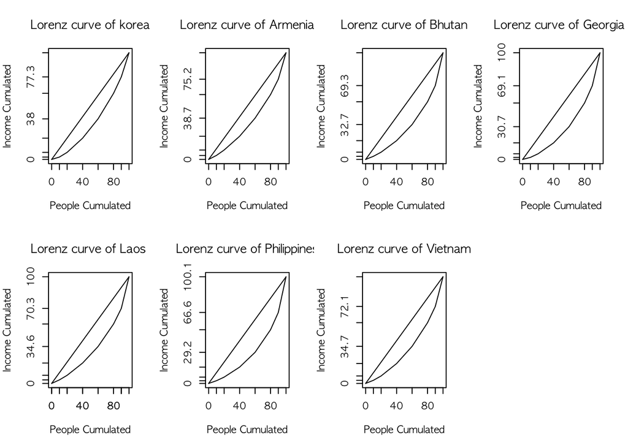

```r
opar<-par(no.readonly=TRUE)
par(mfrow=c(2,4))
plot(x , y1, type="l", ann=FALSE, xaxt="n", yaxt="n")
axis(side=1,at=x, labels=paste(x))
axis(side=2,at=y1, labels=paste(y1))
lines(x = x, y = x)
title(main="Lorenz curve of korea",xlab="People Cumulated",ylab="Income Cumulated")
plot(x , y2, type="l", ann=FALSE, xaxt="n", yaxt="n")
axis(side=1,at=x, labels=paste(x))
axis(side=2,at=y2, labels=paste(y2))
lines(x = x, y = x)
title(main="Lorenz curve of Armenia",xlab="People Cumulated",ylab="Income Cumulated")
plot(x , y3, type="l", ann=FALSE, xaxt="n", yaxt="n")
axis(side=1,at=x, labels=paste(x))
axis(side=2,at=y3, labels=paste(y3))
lines(x = x, y = x)
title(main="Lorenz curve of Bhutan",xlab="People Cumulated",ylab="Income Cumulated")
plot(x , y4, type="l", ann=FALSE, xaxt="n", yaxt="n")
axis(side=1,at=x, labels=paste(x))
axis(side=2,at=y4, labels=paste(y4))
lines(x = x, y = x)
title(main="Lorenz curve of Georgia ",xlab="People Cumulated",ylab="Income Cumulated")
plot(x , y5, type="l", ann=FALSE, xaxt="n", yaxt="n")
axis(side=1,at=x, labels=paste(x))
axis(side=2,at=y5, labels=paste(y5))
lines(x = x, y = x)
title(main="Lorenz curve of Laos ",xlab="People Cumulated",ylab="Income Cumulated")
axis(side=1,at=x, labels=paste(x))
plot(x , y6, type="l", ann=FALSE, xaxt="n", yaxt="n")
axis(side=1,at=x, labels=paste(x))
axis(side=2,at=y6, labels=paste(y6))
lines(x = x, y = x)
title(main="Lorenz curve of Philippines",xlab="People Cumulated",ylab="Income Cumulated")
plot(x , y7, type="l", ann=FALSE, xaxt="n", yaxt="n")
axis(side=1,at=x, labels=paste(x))
axis(side=2,at=y7, labels=paste(y7))
lines(x = x, y = x)
title(main="Lorenz curve of Vietnam",xlab="People Cumulated",ylab="Income Cumulated")
```

북아메리카카 로렌츠 곡선

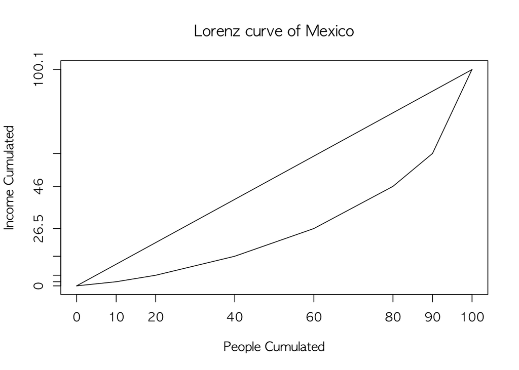

```r
par(mfrow=c(1,1))
plot(x , y8, type="l", ann=FALSE, xaxt="n", yaxt="n")
axis(side=1,at=x, labels=paste(x))
axis(side=2,at=y8, labels=paste(y8))
lines(x = x, y = x)
title(main="Lorenz curve of Mexico",xlab="People Cumulated",ylab="Income Cumulated")
```

남아메리카 국가별 로렌츠 곡선 (1)

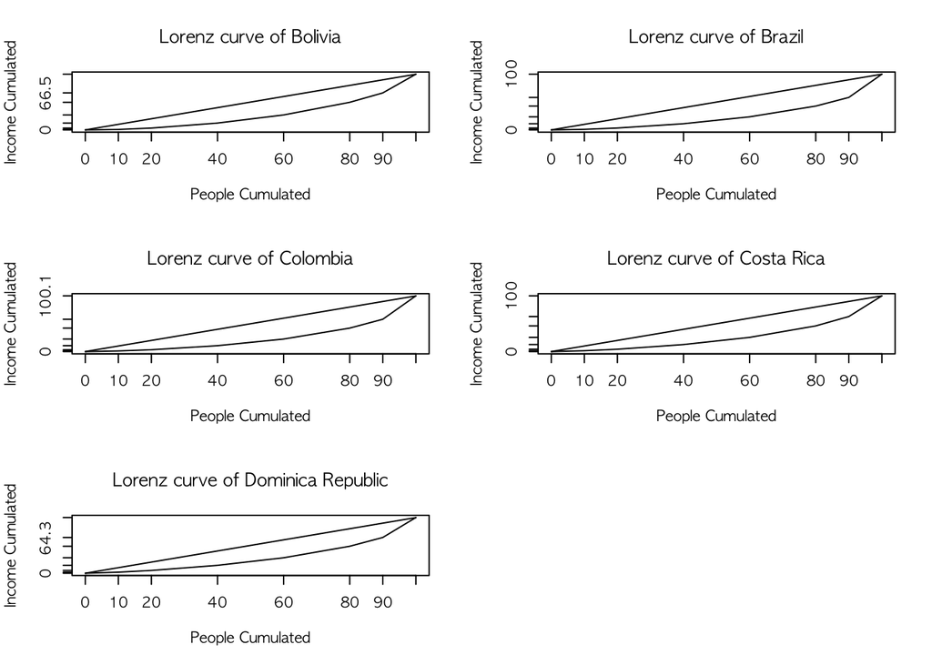

```r
opar<-par(no.readonly=TRUE)
par(mfrow=c(3,2))
plot(x , y9, type="l", ann=FALSE, xaxt="n", yaxt="n")
axis(side=1,at=x, labels=paste(x))
axis(side=2,at=y9, labels=paste(y9))
lines(x = x, y = x)
title(main="Lorenz curve of Bolivia",xlab="People Cumulated",ylab="Income Cumulated")
plot(x , y10, type="l", ann=FALSE, xaxt="n", yaxt="n")
axis(side=1,at=x, labels=paste(x))
axis(side=2,at=y10, labels=paste(y10))
lines(x = x, y = x)
title(main="Lorenz curve of Brazil",xlab="People Cumulated",ylab="Income Cumulated")
plot(x , y11, type="l", ann=FALSE, xaxt="n", yaxt="n")
axis(side=1,at=x, labels=paste(x))
axis(side=2,at=y11, labels=paste(y11))
lines(x = x, y = x)
title(main="Lorenz curve of Colombia",xlab="People Cumulated",ylab="Income Cumulated")
plot(x , y12, type="l", ann=FALSE, xaxt="n", yaxt="n")
axis(side=1,at=x, labels=paste(x))
axis(side=2,at=y12, labels=paste(y12))
lines(x = x, y = x)
title(main="Lorenz curve of Costa Rica",xlab="People Cumulated",ylab="Income Cumulated")
plot(x , y13, type="l", ann=FALSE, xaxt="n", yaxt="n")
axis(side=1,at=x, labels=paste(x))
axis(side=2,at=y13, labels=paste(y13))
lines(x = x, y = x)
title(main="Lorenz curve of Dominica Republic",xlab="People Cumulated",ylab="Income Cumulated")
```

남아메리카 국가별 로렌츠 곡선 (2)

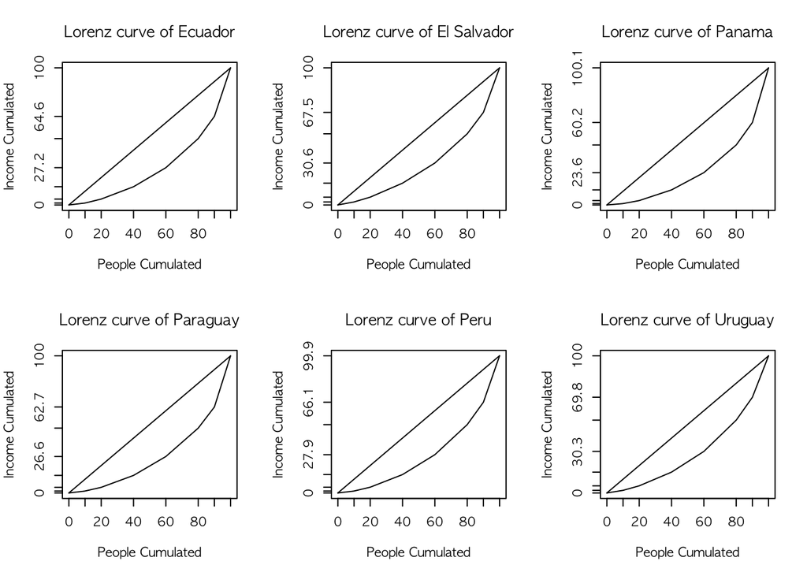

```r
opar<-par(no.readonly=TRUE)
par(mfrow=c(2,3))
plot(x , y14, type="l", ann=FALSE, xaxt="n", yaxt="n")
axis(side=1,at=x, labels=paste(x))
axis(side=2,at=y14, labels=paste(y14))
lines(x = x, y = x)
title(main="Lorenz curve of Ecuador",xlab="People Cumulated",ylab="Income Cumulated")
plot(x , y15, type="l", ann=FALSE, xaxt="n", yaxt="n")
axis(side=1,at=x, labels=paste(x))
axis(side=2,at=y15, labels=paste(y15))
lines(x = x, y = x)
title(main="Lorenz curve of El Salvador",xlab="People Cumulated",ylab="Income Cumulated")
plot(x , y16, type="l", ann=FALSE, xaxt="n", yaxt="n")
axis(side=1,at=x, labels=paste(x))
axis(side=2,at=y16, labels=paste(y16))
lines(x = x, y = x)
title(main="Lorenz curve of Panama",xlab="People Cumulated",ylab="Income Cumulated")
plot(x , y17, type="l", ann=FALSE, xaxt="n", yaxt="n")
axis(side=1,at=x, labels=paste(x))
axis(side=2,at=y17, labels=paste(y17))
lines(x = x, y = x)
title(main="Lorenz curve of Paraguay",xlab="People Cumulated",ylab="Income Cumulated")
plot(x , y18, type="l", ann=FALSE, xaxt="n", yaxt="n")
axis(side=1,at=x, labels=paste(x))
axis(side=2,at=y18, labels=paste(y18))
lines(x = x, y = x)
title(main="Lorenz curve of Peru",xlab="People Cumulated",ylab="Income Cumulated")
plot(x , y19, type="l", ann=FALSE, xaxt="n", yaxt="n")
axis(side=1,at=x, labels=paste(x))
axis(side=2,at=y19, labels=paste(y19))
lines(x = x, y = x)
title(main="Lorenz curve of Uruguay",xlab="People Cumulated",ylab="Income Cumulated")
```

각 유럽별 로렌츠 곡선

[figure not shown]

```r
par(mfrow=c(1,2))
plot(x , y20, type="l", ann=FALSE, xaxt="n", yaxt="n")
axis(side=1,at=x, labels=paste(x))
axis(side=2,at=y20, labels=paste(y20))
lines(x = x, y = x)
title(main="Lorenz curve of Albania",xlab="People Cumulated",ylab="Income Cumulated")
plot(x , y21, type="l", ann=FALSE, xaxt="n", yaxt="n")
axis(side=1,at=x, labels=paste(x))
axis(side=2,at=y21, labels=paste(y22))
lines(x = x, y = x)
title(main="Lorenz curve of Romania",xlab="People Cumulated",ylab="Income Cumulated")
```

각 아프리카별 로렌츠 곡

[figure not shown]

```r
par(mfrow=c(2,2))
plot(x , y22, type="l", ann=FALSE, xaxt="n", yaxt="n")
axis(side=1,at=x, labels=paste(x))
axis(side=2,at=y22, labels=paste(y21))
lines(x = x, y = x)
title(main="Lorenz curve of Guinea",xlab="People Cumulated",ylab="Income Cumulated")
plot(x , y23, type="l", ann=FALSE, xaxt="n", yaxt="n")
axis(side=1,at=x, labels=paste(x))
axis(side=2,at=y23, labels=paste(y23))
lines(x = x, y = x)
title(main="Lorenz curve of Mauritius",xlab="People Cumulated",ylab="Income Cumulated")
plot(x , y24, type="l", ann=FALSE, xaxt="n", yaxt="n")
axis(side=1,at=x, labels=paste(x))
axis(side=2,at=y24, labels=paste(y24))
lines(x = x, y = x)
title(main="Lorenz curve of Tanzania",xlab="People Cumulated",ylab="Income Cumulated")
plot(x , y25, type="l", ann=FALSE, xaxt="n", yaxt="n")
axis(side=1,at=x, labels=paste(x))
axis(side=2,at=y25, labels=paste(y25))
lines(x = x, y = x)
title(main="Lorenz curve of Uganda",xlab="People Cumulated",ylab="Income Cumulated")
```

piketty 소득불평등 자료 행렬 만들기

```r
z0 <- read.xlsx("data A.xlsx", 1, startRow=5, endRow=5, colIndex=2:6, header=FALSE)
z0
```

```
##   X2 X3 X4 X5 X6
## 1 10 20 25 35 50
```

```r
z1 <- read.xlsx("data A.xlsx", 1, startRow=6, endRow=6, colIndex=2:6, header=FALSE)
z1
```

```
##   X2 X3 X4 X5 X6
## 1 20 30 35 35 40
```

```r
z2 <- read.xlsx("data A.xlsx", 1, startRow=7, endRow=7, colIndex=2:6, header=FALSE)
z2
```

```
##   X2 X3 X4 X5 X6
## 1 45 40 35 25  5
```

```r
z3 <- read.xlsx("data A.xlsx", 1, startRow=8, endRow=8, colIndex=2:6, header=FALSE)
z3
```

```
##   X2 X3 X4 X5 X6
## 1 25 10  5  5  5
```

```r
z4<-rbind(z1,z0)
z4
```

```
##   X2 X3 X4 X5 X6
## 1 20 30 35 35 40
## 2 10 20 25 35 50
```

```r
z5<-rbind(z2,z4)
z5
```

```
##   X2 X3 X4 X5 X6
## 1 45 40 35 25  5
## 2 20 30 35 35 40
## 3 10 20 25 35 50
```

```r
z6<-rbind(z3,z5)
z6
```

```
##   X2 X3 X4 X5 X6
## 1 25 10  5  5  5
## 2 45 40 35 25  5
## 3 20 30 35 35 40
## 4 10 20 25 35 50
```

```r
y0 <- c(0,0,0,0,0)
z7<- rbind(y0, z6)
z7
```

```
##   X2 X3 X4 X5 X6
## 1  0  0  0  0  0
## 2 25 10  5  5  5
## 3 45 40 35 25  5
## 4 20 30 35 35 40
## 5 10 20 25 35 50
```

```r
x1 <- c(0,50,90,99,100)
cbind(x1, z7)
```

```
##    x1 X2 X3 X4 X5 X6
## 1   0  0  0  0  0  0
## 2  50 25 10  5  5  5
## 3  90 45 40 35 25  5
## 4  99 20 30 35 35 40
## 5 100 10 20 25 35 50
```

```r
z9 <- cbind(x1,z7)
z9
```

```
##    x1 X2 X3 X4 X5 X6
## 1   0  0  0  0  0  0
## 2  50 25 10  5  5  5
## 3  90 45 40 35 25  5
## 4  99 20 30 35 35 40
## 5 100 10 20 25 35 50
```

```r
dimnames(z9)[[2]] <- c("x(%)","low","medium","medium-high","high","very-high")
z9
```

```
##   x(%) low medium medium-high high very-high
## 1    0   0      0           0    0         0
## 2   50  25     10           5    5         5
## 3   90  45     40          35   25         5
## 4   99  20     30          35   35        40
## 5  100  10     20          25   35        50
```

```r
z10 <- cbind(x = z9[,1], apply(z9[, 2:6], 2, cumsum))
z10
```

```
##     x low medium medium-high high very-high
## 1   0   0      0           0    0         0
## 2  50  25     10           5    5         5
## 3  90  70     50          40   30        10
## 4  99  90     80          75   65        50
## 5 100 100    100         100  100       100
```

```r
z11<-z10[,2]
z11
```

```
##   1   2   3   4   5
##   0  25  70  90 100
```

각 나라별 로렌츠 곡선 만들기 및 표와 제목과 부제목 달기.

[figure not shown]

```r
opar<-par(no.readonly=TRUE)
par(mfrow=c(1,1))
y<-c(0,5,10,15,20,25,30,35,40,45,50,55,60,65,70,75,80,85,90,95,100)
plot(z10[,1] , z11, type="l", ann=FALSE, xaxt="n", yaxt="n")
axis(side = 1, at = x, labels = paste(x))
axis(side = 2, at = y, labels = paste(y))
lines(x=x,y=x)
lines(x=x,y=y1,col="blue")
lines(x=x,y=y8,col="red")
lines(x=x,y=y10,col="cyan")
lines(x=x,y=y20, col="green")
lines(x=x,y=y25,col="purple")
title(main="각 나라 로렌츠 곡선 비교",xlab="People Cumulated",ylab="Income Cumulated")
legend(x=5,y=95, legend=c("low","korea","Mexcio","Brazil","Albania","Uganda"),lty=1,col=c("black","blue","cyan","green","purple"),title="income inequality")
```

이제 area.R이라는 함수를 이용하여 각 나라별(한국,멕시코, 브라질, 알바니아, 우간다) 및 piketty low 수입의 지니계수를 구한다.

```r
area.R <- function(x, y) {

  sum(diff(x) * (head(y, -1) + tail(y, -1))/2)

}

50-area.R(z10[,1], z10[,2])/100
```

```
## [1] 16.6
```

```r
50-area.R(x, y1)/100
```

```
## [1] 15.2
```

```r
50-area.R(x, y8)/100
```

```
## [1] 23.01
```

```r
50-area.R(x, y10)/100
```

```
## [1] 25.22
```

```r
50-area.R(x, y20)/100
```

```
## [1] 13.955
```

```r
50-area.R(x, y25)/100
```

```
## [1] 21.335
```

ggplot을 설치하기 위해, newdata10, z10을 다시 부른다.

```r
newdata10
```

```
##              x    2     3     4     5     6     7    8    10    12    13
## y0           0  0.0   0.0   0.0   0.0   0.0   0.0  0.0   0.0   0.0   0.0
## datadown10  10  2.2   3.7   2.9   1.9   3.3   2.5  2.9   1.9   0.8   1.0
##             20  6.6   8.8   6.8   5.3   7.6   5.9  7.0   4.9   3.3   3.4
## X4          40 19.9  21.7  17.6  15.5  19.1  15.3 18.6  13.7  12.3  11.1
## X5          60 38.0  38.7  32.7  30.7  34.6  29.2 34.7  26.5  26.9  23.5
## X6          80 61.9  60.8  54.1  52.9  55.7  50.4 56.9  46.0  49.6  42.8
##             90 77.3  75.2  69.3  69.1  70.3  66.6 72.1  61.2  66.5  58.3
##            100 99.9 100.0 100.1 100.0 100.0 100.1 99.9 100.1 100.1 100.0
##               14    15    16    17    18    19    20   21    22    24
## y0           0.0   0.0   0.0   0.0   0.0   0.0   0.0  0.0   0.0   0.0
## datadown10   1.1   1.5   1.9   1.4   2.2   1.0   1.4  1.4   1.9   3.7
##              3.3   4.2   5.0   4.3   5.7   3.2   4.1  4.2   5.2   8.9
## X4          10.6  12.6  14.2  13.3  15.9  11.0  12.8 13.4  15.2  22.1
## X5          22.5  25.5  27.8  27.2  30.6  23.6  26.6 27.9  30.3  39.4
## X6          42.2  46.1  48.5  48.4  51.9  43.8  47.3 49.8  53.1  62.2
##             58.1  62.9  64.3  64.6  67.5  60.2  62.7 66.1  69.8  77.1
##            100.1 100.0 100.1 100.0 100.0 100.1 100.0 99.9 100.0 100.0
##               25    27    28   29    30
## y0           0.0   0.0   0.0  0.0   0.0
## datadown10   3.7   3.1   3.0  3.2   2.5
##              8.9   7.6   7.4  7.4   5.8
## X4          22.7  19.7  19.1 18.4  15.1
## X5          40.6  36.2  34.9 33.4  28.7
## X6          63.8  58.5  56.5 54.2  49.0
##             78.6  73.6  71.2 68.8  64.3
##            100.1 100.1 100.1 99.9 100.1
```

```r
z10
```

```
##     x low medium medium-high high very-high
## 1   0   0      0           0    0         0
## 2  50  25     10           5    5         5
## 3  90  70     50          40   30        10
## 4  99  90     80          75   65        50
## 5 100 100    100         100  100       100
```

```r
#install.packages("reshape2",repos="http://cran.rstudio.com")
library(reshape2)
```

piketty data를 부르고, 표를 만든다.

```r
(piketty <- data.frame(cumulated.people=z10[,1],perfect=z10[,1],low= z10[,2]))
```

```
##   cumulated.people perfect low
## 1                0       0   0
## 2               50      50  25
## 3               90      90  70
## 4               99      99  90
## 5              100     100 100
```

피캐티 자료를 부른다.

```r
(piketty.melt<-melt(piketty,id.vars = "cumulated.people", measure.vars=c("perfect","low"), variable.name="difference", value.name="cumulated.income"))
```

```
##    cumulated.people difference cumulated.income
## 1                 0    perfect                0
## 2                50    perfect               50
## 3                90    perfect               90
## 4                99    perfect               99
## 5               100    perfect              100
## 6                 0        low                0
## 7                50        low               25
## 8                90        low               70
## 9                99        low               90
## 10              100        low              100
```

각 나라별 분포곡선ㅇ 부른다.

```r
(newdata10.2 <- data.frame(cumulated.people=newdata10[,1],Korea= newdata10[,2],Mexico= newdata10[,9],Brazil= newdata10[,11],Albania= newdata10[,21],Uganda= newdata10[,26]))
```

```
##   cumulated.people Korea Mexico Brazil Albania Uganda
## 1                0   0.0    0.0    0.0     0.0    0.0
## 2               10   2.2    1.9    1.0     3.7    2.5
## 3               20   6.6    4.9    3.4     8.9    5.8
## 4               40  19.9   13.7   11.1    22.1   15.1
## 5               60  38.0   26.5   23.5    39.4   28.7
## 6               80  61.9   46.0   42.8    62.2   49.0
## 7               90  77.3   61.2   58.3    77.1   64.3
## 8              100  99.9  100.1  100.0   100.0  100.1
```

```r
(income.melt<-melt(newdata10.2,id.vars = "cumulated.people", measure.vars=c("Korea","Mexico","Brazil","Albania","Uganda"), variable.name="Nation", value.name="cumulated.income"))
```

```
##    cumulated.people  Nation cumulated.income
## 1                 0   Korea              0.0
## 2                10   Korea              2.2
## 3                20   Korea              6.6
## 4                40   Korea             19.9
## 5                60   Korea             38.0
## 6                80   Korea             61.9
## 7                90   Korea             77.3
## 8               100   Korea             99.9
## 9                 0  Mexico              0.0
## 10               10  Mexico              1.9
## 11               20  Mexico              4.9
## 12               40  Mexico             13.7
## 13               60  Mexico             26.5
## 14               80  Mexico             46.0
```

[output cut: 26 more lines]

```r
str(income.melt)
```

```
## 'data.frame':    40 obs. of  3 variables:
##  $ cumulated.people: num  0 10 20 40 60 80 90 100 0 10 ...
##  $ Nation          : Factor w/ 5 levels "Korea","Mexico",..: 1 1 1 1 1 1 1 1 2 2 ...
##  $ cumulated.income: num  0 2.2 6.6 19.9 38 61.9 77.3 99.9 0 1.9 ...
```

ggplot을 설치한다.

```r
library(ggplot2)
```

그래프를 그린다.

```r
source("theme_kr.R")
theme.kr
```

[output not shown]

[output cut: 18 more lines]

[output not shown]

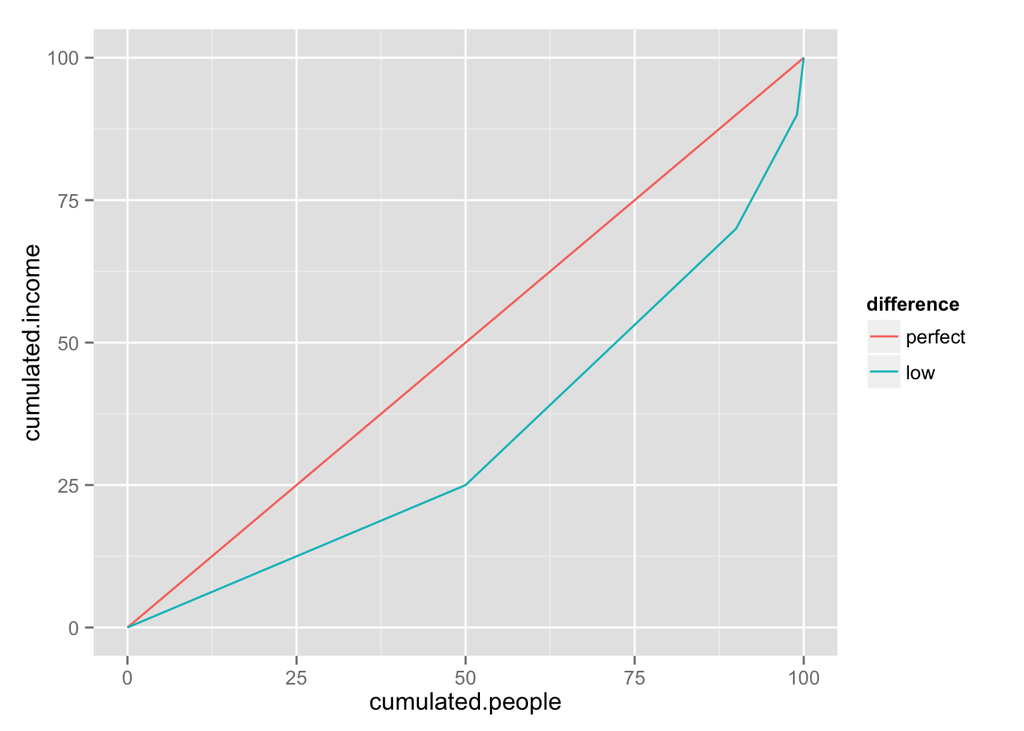

```r
(I.W.1 <- ggplot(piketty.melt,aes(x=cumulated.people, y=cumulated.income, colour=difference, group=difference)) + geom_line())
```

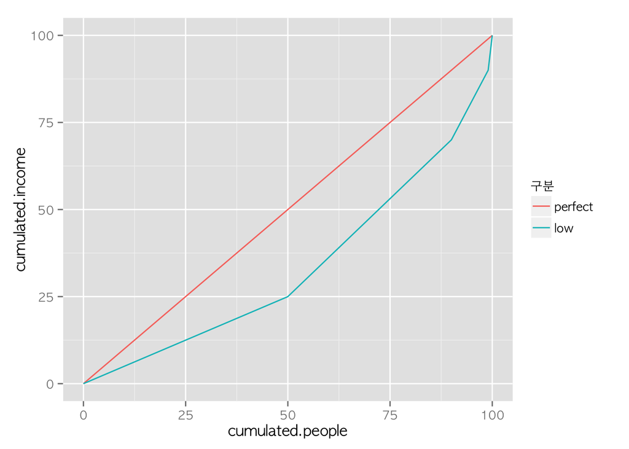

```r
I.W.1 + theme.kr + labs(colour="구분")
```

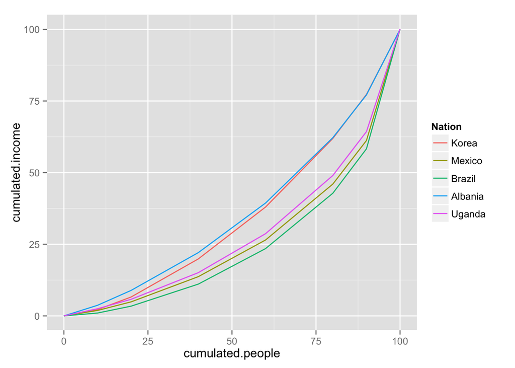

```r
(I.W.2 <- ggplot(income.melt, aes(x=cumulated.people, y=cumulated.income, colour=Nation, group=Nation)) + geom_line())
```

이제 2가지의 자료를 겹친다.

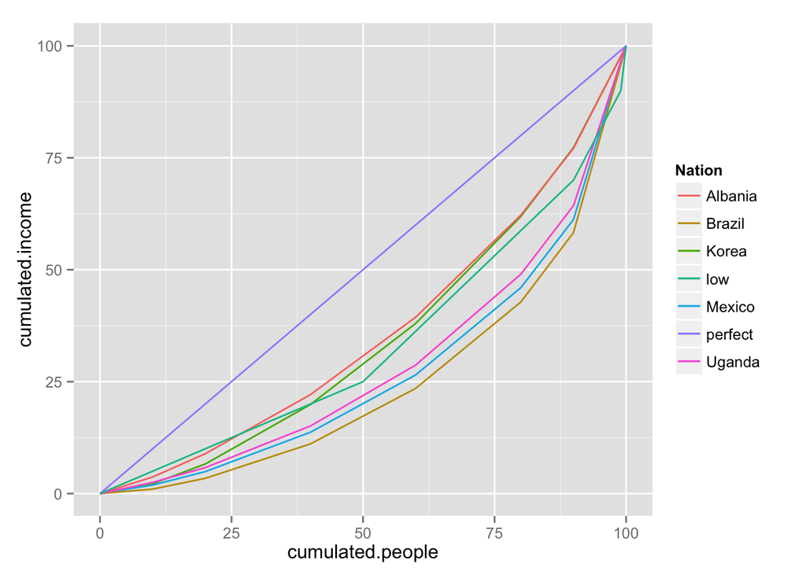

```r
(I.W.3 <- I.W.2 + geom_line(data=piketty.melt, aes(x=cumulated.people, y=cumulated.income, colour=difference, group=difference)))
```

뒷 배경은 하얀배경으로 바꾼다.

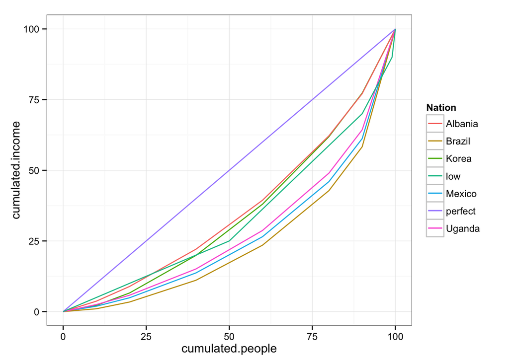

```r
(I.W.4 <- I.W.3 + theme_bw())
```

범례 제목을 한글로 수정한다.

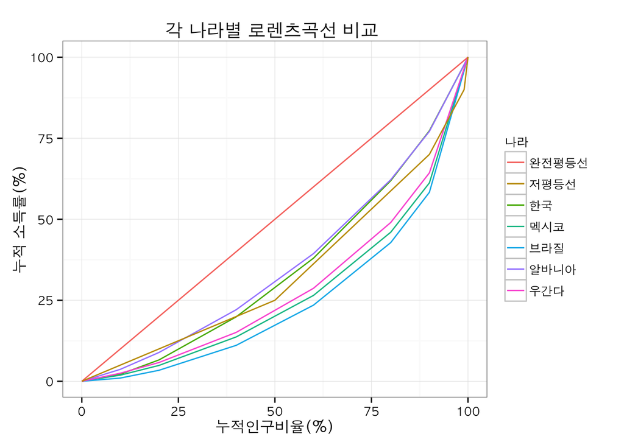

```r
source("theme_kr.R")
#(I.W.5 <- I.W.4 + theme.kr + xlab("누적인구비율(%)") + ylab("누적 소득률(%)") +
# ggtitle("각 나라별 로렌츠곡선 비교 ") + labs(colour="나라") + scale_colour_discrete(labels = c("알바니아", "브라질", "한국", "저불평등", "멕시코", "완전평등선", "우간다"))
(I.W.5 <- I.W.4 + theme.kr + xlab("누적인구비율(%)") + ylab("누적 소득률(%)") +
 ggtitle("각 나라별 로렌츠곡선 비교 ") + labs(colour="나라") + scale_colour_discrete(labels = c("완전평등선", "저평등선", "한국", "멕시코", "브라질", "알바니아", "우간다"), limits=c("perfect", "low", "Korea", "Mexico", "Brazil", "Albania", "Uganda")))
```

```r
# (I.W.6 <- I.W.5 + labs(colour="나라") +scale_colour_discrete(labels = c("알바니아", "브라질","한국","저불평등","멕시코","완전평등선","우간다")))
```